# multicolinealidad

Carlos Carbone

6/11/2021

## Multicolinealidad

Mide el grado de asociación lineal entre las variables (Xi,Xj).

Podemos ver que una variable se relacion con la otra por ejemplo X2=2*X1. Como la calculamos:
$$cor(x_i,x_k)\not = k$$
Si el valor de k=1 o k=-1 Tener en cuenta que no aplica para relacines NO lineales:
$$Y=\beta_0+\beta_1*X_1+\beta_2*X_1^2$$
No aplica porque no viola el supuesto de multicolinealidad, eso va a pasar siempre que $X_1$ tenga una variación en la muestra realtivamente grande, de no ser así no se distanciaria mucho de $X_1^2$ y si habría multicolinealidad.

### 2 Verdadero o Falso:

1. a pesar de la multicolinealididad perfecta, los estimadores de MCO son MELI.

FALSO. Si hay multicolinealidad perfecta los coeficientes de resgresion de las vvariables X son indeterminados y sus rrores estandar son infinitos. Los estimadores no son MELI ya no que no cumplen con el supuesto de Gauss- Markov

2. Las correlaciones altas entre parejas de regresoras no sugieren una alta multicolinealidad.

FALSO. Si la correlacion es alta presisamente sujiere multicolinealidad alta.

### Cree una variable x1 = rnorm(30000,1,2).

```r
  x1<-rnorm(3000,1,2)
```

1. Obtenga a x2 como x1+rnorm(30000,0,1).

```r
  x2<-x1+rnorm(3000,0,1)
```

2. Obtenga la correlación entre x1 y x2.

```r
    cor(x1,x2)
```

```
## [1] 0.8924821
```

3. Obtenga a y como 2+5*x1+2*x2+rnorm(30000,0,1). ¿Qué sucede?

```r
    y=2+5*x1+2*x2+rnorm(3000,0,1)
    datos=data.frame(y,x1,x2)
library(GGally)
```

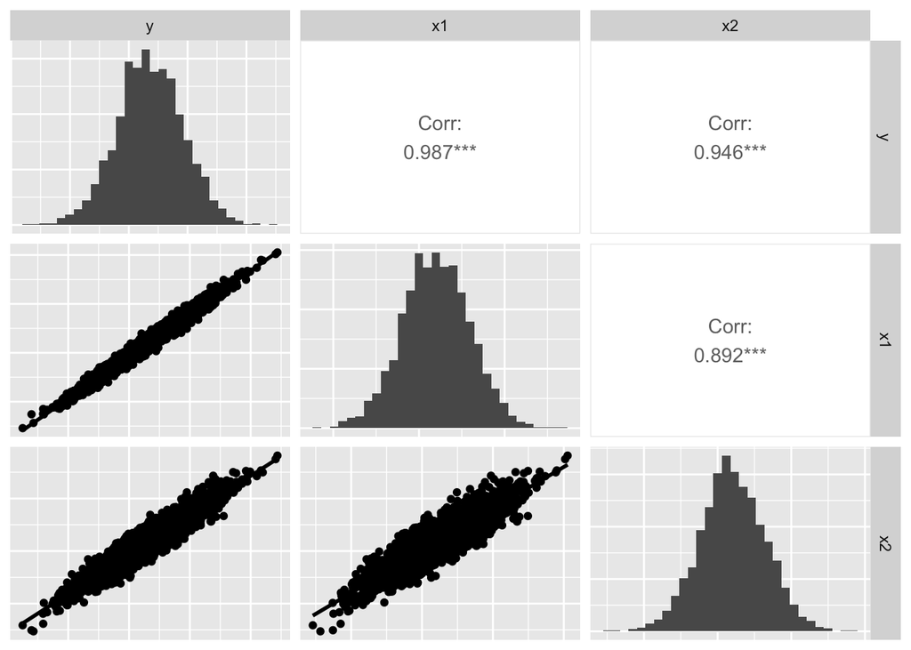

```r
ggpairs(datos, lower = list(continuous = "smooth"),
        diag = list(continuous = "bar"), axisLabels = "none")
```

4. Realice una regresión entre y, x1 y x2.

```r
  regressor_ejer_3<-lm(y~.,data = datos)

  summary(regressor_ejer_3)
```

```
##
## Call:
## lm(formula = y ~ ., data = datos)
##
## Residuals:
##     Min      1Q  Median      3Q     Max
## -3.2158 -0.6825  0.0193  0.6831  3.1412
##
## Coefficients:
##             Estimate Std. Error t value Pr(>|t|)
## (Intercept)  1.99281    0.02094   95.16   <2e-16 ***
## x1           4.95409    0.02091  236.90   <2e-16 ***
## x2           2.02812    0.01869  108.50   <2e-16 ***
## ---
## Signif. codes:  0 '***' 0.001 '**' 0.01 '*' 0.05 '.' 0.1 ' ' 1
##
## Residual standard error: 1.028 on 2997 degrees of freedom
## Multiple R-squared:  0.9947, Adjusted R-squared:  0.9947
## F-statistic: 2.796e+05 on 2 and 2997 DF,  p-value: < 2.2e-16
```

A pesar de tener una alta correlacion entre x1 y x2 ambos dan que son significativos.

### 4) Cree una variable x1 = rnorm(30000,1,2).

```r
  x1<-rnorm(3000,1,2)
```

1. Obtenga a x2 como x1+rnorm(30000,0,0.001)

```r
  x2<-x1+rnorm(3000,0,0.001)
```

2. Obtenga la correlación entre x1 y x2. ¿Qué sucede?

```r
 cor(x1,x2)
```

```
## [1] 0.9999999
```

Se puede observar una correlacion casi perfecta

3. Obtenga a y como 2+5*x1+2*x2+rnorm(30000,0,1).

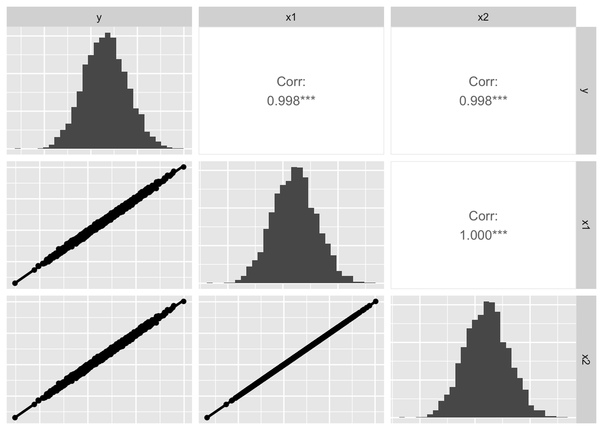

```r
    y=2+5*x1+2*x2+rnorm(3000,0,1)
    datos=data.frame(y,x1,x2)
library(GGally)
ggpairs(datos, lower = list(continuous = "smooth"),
                diag = list(continuous = "bar"), axisLabels = "none")
```

4. Realice una regresión entre y, x1 y x2. ¿Qué sucede?

```r
  regressor_ejer_3<-lm(y~.,data = datos)

  summary(regressor_ejer_3)
```

```
##
## Call:
## lm(formula = y ~ ., data = datos)
##
## Residuals:
##     Min      1Q  Median      3Q     Max
## -3.5952 -0.6742  0.0020  0.6594  3.3519
##
## Coefficients:
##             Estimate Std. Error t value Pr(>|t|)
## (Intercept)  1.98760    0.02026  98.087   <2e-16 ***
## x1           9.96096   17.87233   0.557    0.577
## x2          -2.95065   17.87245  -0.165    0.869
## ---
## Signif. codes:  0 '***' 0.001 '**' 0.01 '*' 0.05 '.' 0.1 ' ' 1
##
## Residual standard error: 0.9818 on 2997 degrees of freedom
## Multiple R-squared:  0.9951, Adjusted R-squared:  0.9951
## F-statistic: 3.037e+05 on 2 and 2997 DF,  p-value: < 2.2e-16
```

Aca vemos que solo el intercepto da significativo.

## 6

```r
rm(list=ls())
library(stargazer)
```

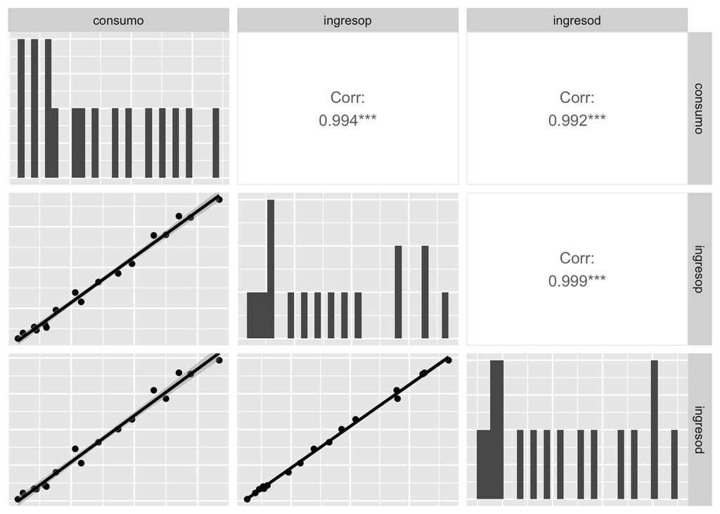

```r
consumo=c(6127.9,
          6863.1,
          10687.4,
          5518.4,
          9783.9,
          4828.9,
          8614.3,
          4311.9,
          5216.1,
          7486.6,
          4898.3,
          7924.3,
          4473.3,
          9409.9,
          9000.1,
          6316.5,
          5176.0)

ingresop=c(8467.0,
           9113.0,
           14162.0,
           7392.0,
           13067.0,
           6357.0,
           11969.0,
           5647.0,
           6323.0,
           9638.0,
           6159.0,
           10229.0,
           5989.0,
           13147.0,
           12003.0,
           7895.0,
           6500.0)

ingresod=c(79.1,
           82.8,
           128.7,
           66.0,
           121.0,
           56.8,
           111.9,
           50.9,
           58.0,
           90.1,
           56.5,
           95.6,
           54.4,
           121.7,
           107.2,
           71.1,
           58.6)

datos=data.frame(consumo,ingresop,ingresod)

library(GGally)
ggpairs(datos, lower = list(continuous = "smooth"),
        diag = list(continuous = "bar"), axisLabels = "none")
```

Aca vemos que hay una alta correlacion, pero no perfecta, en cmabio con el en ingresoD e ingresoP hay una correlacion muy alta 0.999 por lo que vamos a tener un problema de multicolinealidad. Una forma de solucionarlo es quitarlo del modelo.

```r
reg<-lm(consumo~.,data = datos)
summary(reg)
```

```
##
## Call:
## lm(formula = consumo ~ ., data = datos)
##
## Residuals:
##     Min      1Q  Median      3Q     Max
## -322.32 -195.70  -15.74  178.67  304.74
##
## Coefficients:
##             Estimate Std. Error t value Pr(>|t|)
## (Intercept) 419.8450   198.4564   2.116   0.0528 .
## ingresop      0.9307     0.3807   2.445   0.0283 *
## ingresod    -24.0271    40.8252  -0.589   0.5655
## ---
## Signif. codes:  0 '***' 0.001 '**' 0.01 '*' 0.05 '.' 0.1 ' ' 1
##
## Residual standard error: 230.6 on 14 degrees of freedom
## Multiple R-squared:  0.9889, Adjusted R-squared:  0.9873
## F-statistic: 625.1 on 2 and 14 DF,  p-value: 2.042e-14
```

Al correr la regresion podemos observar tambien que R^2 ajustado es muy alto, pero los regresores son muy pocos significativos.

Ahora probamos quitando el consumoP y ConsumoD del modelo

```r
regPesos<-lm(consumo~datos$ingresop ,data = datos)
regDolares<-lm(consumo~datos$ingresod,data = datos)

stargazer(reg,regPesos,regDolares,type="text")
```

```
##
## =============================================================================================
##                                                Dependent variable:
##                     -------------------------------------------------------------------------
##                                                      consumo
##                               (1)                      (2)                      (3)
## ---------------------------------------------------------------------------------------------
## ingresop                    0.931**
##                             (0.381)
##
## ingresod                    -24.027
##                            (40.825)
##
## ingresop                                            0.707***
##                                                      (0.020)
##
## ingresod                                                                     75.637***
##                                                                               (2.474)
##
## Constant                   419.845*                 454.250**                585.825**
##                            (198.456)                (185.473)                (215.200)
##
## ---------------------------------------------------------------------------------------------
## Observations                  17                       17                       17
## R2                           0.989                    0.989                    0.984
## Adjusted R2                  0.987                    0.988                    0.983
## Residual Std. Error    230.579 (df = 14)        225.500 (df = 15)        266.091 (df = 15)
## F Statistic         625.118*** (df = 2; 14) 1,306.835*** (df = 1; 15) 934.312*** (df = 1; 15)
## =============================================================================================
## Note:                                                             *p<0.1; **p<0.05; ***p<0.01
```